# A Whale off the Port(folio)

In this assignment, you'll get to use what you've learned this week to evaluate the performance among various algorithmic, hedge, and mutual fund portfolios and compare them against the S&P TSX 60 Index.

```python
# Initial imports
import pandas as pd
import numpy as np
import datetime as dt
from pathlib import Path
import matplotlib.pyplot as plt
plt.style.use('ggplot')

%matplotlib inline
```

# Data Cleaning

In this section, you will need to read the CSV files into DataFrames and perform any necessary data cleaning steps. After cleaning, combine all DataFrames into a single DataFrame.

Files:

- `whale_returns.csv`: Contains returns of some famous "whale" investors' portfolios.
- `algo_returns.csv`: Contains returns from the in-house trading algorithms from Harold's company.
- `sp_tsx_history.csv`: Contains historical closing prices of the S&P TSX 60 Index.

## Whale Returns

Read the Whale Portfolio daily returns and clean the data.

```python
# Reading whale returns
whale_df = pd.read_csv("Resources/whale_returns.csv")
whale_df['Date'] = pd.to_datetime(whale_df['Date'], infer_datetime_format=True)
whale_df.set_index('Date', inplace=True)
whale_df.head()
```

| Date | SOROS FUND MANAGEMENT LLC | PAULSON & CO.INC. | TIGER GLOBAL MANAGEMENT LLC | BERKSHIRE HATHAWAY INC |
| --- | --- | --- | --- | --- |
| 2015-03-02 | NaN | NaN | NaN | NaN |
| 2015-03-03 | -0.001266 | -0.004981 | -0.000496 | -0.006569 |
| 2015-03-04 | 0.002230 | 0.003241 | -0.002534 | 0.004213 |
| 2015-03-05 | 0.004016 | 0.004076 | 0.002355 | 0.006726 |
| 2015-03-06 | -0.007905 | -0.003574 | -0.008481 | -0.013098 |

```python
# Count nulls
whale_df.isnull().sum()
```

```
SOROS FUND MANAGEMENT LLC      1
PAULSON & CO.INC.              1
TIGER GLOBAL MANAGEMENT LLC    1
BERKSHIRE HATHAWAY INC         1
dtype: int64
```

```python
# Drop nulls
whale_clean= whale_df.dropna()
```

```python
#test
whale_clean.isnull().sum()
```

```
SOROS FUND MANAGEMENT LLC      0
PAULSON & CO.INC.              0
TIGER GLOBAL MANAGEMENT LLC    0
BERKSHIRE HATHAWAY INC         0
dtype: int64
```

## Algorithmic Daily Returns

Read the algorithmic daily returns and clean the data.

```python
# Reading algorithmic returns
algo_df = pd.read_csv('Resources/algo_returns.csv')
algo_df['Date'] = pd.to_datetime(algo_df['Date'], infer_datetime_format=True)
algo_df.set_index('Date', inplace=True)
algo_df
```

| Date | Algo 1 | Algo 2 |
| --- | --- | --- |
| 2014-05-28 | 0.001745 | NaN |
| 2014-05-29 | 0.003978 | NaN |
| 2014-05-30 | 0.004464 | NaN |
| 2014-06-02 | 0.005692 | NaN |
| 2014-06-03 | 0.005292 | NaN |
| ... | ... | ... |
| 2019-04-25 | 0.000682 | -0.007247 |
| 2019-04-26 | 0.002981 | 0.005256 |
| 2019-04-29 | 0.005208 | 0.002829 |
| 2019-04-30 | -0.002944 | -0.001570 |
| 2019-05-01 | 0.000094 | -0.007358 |

1241 rows × 2 columns

```python
# Count nulls
algo_df.isnull().sum(axis = 0)
```

```
Algo 1    0
Algo 2    6
dtype: int64
```

```python
# Drop nulls
algo_clean= algo_df.dropna()
algo_clean.isnull().sum(axis = 0)
```

```
Algo 1    0
Algo 2    0
dtype: int64
```

## S&P TSX 60 Returns

Read the S&P TSX 60 historic closing prices and create a new daily returns DataFrame from the data.

```python
# Reading S&P TSX 60 Closing Prices
sp_tsx_df  = pd.read_csv('Resources/sp_tsx_history.csv')
sp_tsx_df['Date'] = pd.to_datetime(sp_tsx_df['Date'], infer_datetime_format=True)
sp_tsx_df.set_index('Date', inplace=True)
sp_tsx_df
```

| Date | Close |
| --- | --- |
| 2012-10-01 | $12,370.19 |
| 2012-10-02 | $12,391.23 |
| 2012-10-03 | $12,359.47 |
| 2012-10-04 | $12,447.68 |
| 2012-10-05 | $12,418.99 |
| ... | ... |
| 2019-12-20 | $17,118.44 |
| 2019-12-23 | $17,128.71 |
| 2019-12-24 | $17,180.15 |
| 2019-12-27 | $17,168.21 |
| 2019-12-30 | $17,098.56 |

1818 rows × 1 columns

```python
# Check Data Types
sp_tsx_df.dtypes
```

```
Close    object
dtype: object
```

```python
# Fix Data Types
sp_tsx_df["Close"] = sp_tsx_df["Close"].str.replace("$", "",regex= True)
sp_tsx_df["Close"] = sp_tsx_df["Close"].str.replace(",", "",regex= True).astype(float)
sp_tsx_df.dtypes
```

```
Close    float64
dtype: object
```

```python
# Calculate Daily Returns
daily_returns_sp_tsx = sp_tsx_df.pct_change()
daily_returns_sp_tsx
```

| Date | Close |
| --- | --- |
| 2012-10-01 | NaN |
| 2012-10-02 | 0.001701 |
| 2012-10-03 | -0.002563 |
| 2012-10-04 | 0.007137 |
| 2012-10-05 | -0.002305 |
| ... | ... |
| 2019-12-20 | 0.003188 |
| 2019-12-23 | 0.000600 |
| 2019-12-24 | 0.003003 |
| 2019-12-27 | -0.000695 |
| 2019-12-30 | -0.004057 |

1818 rows × 1 columns

```python
# Drop nulls
daily_returns_sp_tsx= daily_returns_sp_tsx.dropna()
daily_returns_sp_tsx.head()
```

| Date | Close |
| --- | --- |
| 2012-10-02 | 0.001701 |
| 2012-10-03 | -0.002563 |
| 2012-10-04 | 0.007137 |
| 2012-10-05 | -0.002305 |
| 2012-10-09 | -0.011709 |

```python
# Rename `Close` Column to be specific to this portfolio.
daily_returns_sp_tsx = daily_returns_sp_tsx.rename(columns={'Close':'S&P TSX 60'})
daily_returns_sp_tsx.head()
```

| Date | S&P TSX 60 |
| --- | --- |
| 2012-10-02 | 0.001701 |
| 2012-10-03 | -0.002563 |
| 2012-10-04 | 0.007137 |
| 2012-10-05 | -0.002305 |
| 2012-10-09 | -0.011709 |

## Combine Whale, Algorithmic, and S&P TSX 60 Returns

```python
# Join Whale Returns, Algorithmic Returns, and the S&P TSX 60 Returns into a single DataFrame with columns for each portfolio's returns.
combine_all_df= pd.concat([whale_clean, algo_df, daily_returns_sp_tsx], axis="columns", join="inner")
combine_all_df.sort_index(inplace=True)
# Set column names

combine_all_df.head()
```

| Date | SOROS FUND MANAGEMENT LLC | PAULSON & CO.INC. | TIGER GLOBAL MANAGEMENT LLC | BERKSHIRE HATHAWAY INC | Algo 1 | Algo 2 | S&P TSX 60 |
| --- | --- | --- | --- | --- | --- | --- | --- |
| 2015-03-03 | -0.001266 | -0.004981 | -0.000496 | -0.006569 | -0.001942 | -0.000949 | -0.008530 |
| 2015-03-04 | 0.002230 | 0.003241 | -0.002534 | 0.004213 | -0.008589 | 0.002416 | -0.003371 |
| 2015-03-05 | 0.004016 | 0.004076 | 0.002355 | 0.006726 | -0.000955 | 0.004323 | 0.001344 |
| 2015-03-06 | -0.007905 | -0.003574 | -0.008481 | -0.013098 | -0.004957 | -0.011460 | -0.009972 |
| 2015-03-09 | 0.000582 | 0.004225 | 0.005843 | -0.001652 | -0.005447 | 0.001303 | -0.006555 |

# Conduct Quantitative Analysis

In this section, you will calculate and visualize performance and risk metrics for the portfolios.

## Performance Anlysis

#### Calculate and Plot the daily returns.

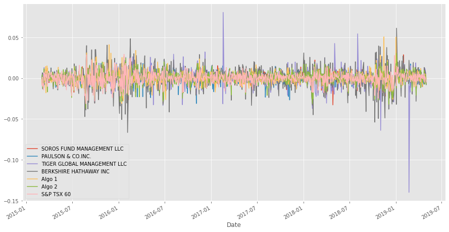

```python
# Plot daily returns of all portfolios
combine_all_df.plot(figsize=(15,8))
plt.show()
```

#### Calculate and Plot cumulative returns.

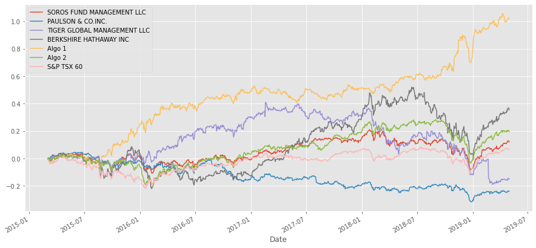

```python
# Calculate cumulative returns of all portfolios

# Plot cumulative returns
cumulative_returns = (1 + combine_all_df).cumprod() - 1
cumulative_returns.plot(figsize=(15,7))
plt.show()
```

## Risk Analysis

Determine the *risk* of each portfolio:

1. Create a box plot for each portfolio.
2. Calculate the standard deviation for all portfolios.
3. Determine which portfolios are riskier than the S&P TSX 60.
4. Calculate the Annualized Standard Deviation.

### Create a box plot for each portfolio

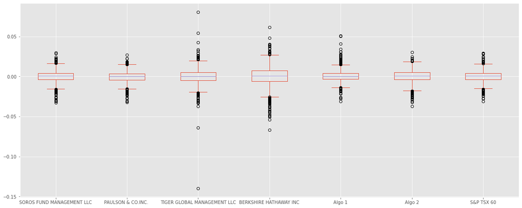

```python
# Box plot to visually show risk
combine_all_df.plot.box(figsize=(20,8))
plt.show()
```

### Calculate Standard Deviations

```python
# Calculate the daily standard deviations of all portfolios
portfolio_daily_std= combine_all_df.std()
portfolio_daily_std.sort_values(ascending=False)
```

```
BERKSHIRE HATHAWAY INC         0.012826
TIGER GLOBAL MANAGEMENT LLC    0.010883
Algo 2                         0.008326
SOROS FUND MANAGEMENT LLC      0.007828
Algo 1                         0.007589
S&P TSX 60                     0.007034
PAULSON & CO.INC.              0.006982
dtype: float64
```

### Determine which portfolios are riskier than the S&P TSX 60

```python
# Calculate  the daily standard deviation of S&P TSX 60

# Determine which portfolios are riskier than the S&P TSX 60
sp500_daily_std= portfolio_daily_std["S&P TSX 60"]
print(portfolio_daily_std > sp500_daily_std)
```

```
SOROS FUND MANAGEMENT LLC       True
PAULSON & CO.INC.              False
TIGER GLOBAL MANAGEMENT LLC     True
BERKSHIRE HATHAWAY INC          True
Algo 1                          True
Algo 2                          True
S&P TSX 60                     False
dtype: bool
```

### Calculate the Annualized Standard Deviation

```python
# Calculate the annualized standard deviation (252 trading days)
annualized_std = portfolio_daily_std * np.sqrt(252)
annualized_std
```

```
SOROS FUND MANAGEMENT LLC      0.124259
PAULSON & CO.INC.              0.110841
TIGER GLOBAL MANAGEMENT LLC    0.172759
BERKSHIRE HATHAWAY INC         0.203599
Algo 1                         0.120470
Algo 2                         0.132177
S&P TSX 60                     0.111664
dtype: float64
```

## Rolling Statistics

Risk changes over time. Analyze the rolling statistics for Risk and Beta.

1. Calculate and plot the rolling standard deviation for all portfolios using a 21-day window.
2. Calculate the correlation between each stock to determine which portfolios may mimick the S&P TSX 60.
3. Choose one portfolio, then calculate and plot the 60-day rolling beta for it and the S&P TSX 60.

### Calculate and plot rolling `std` for all portfolios with 21-day window

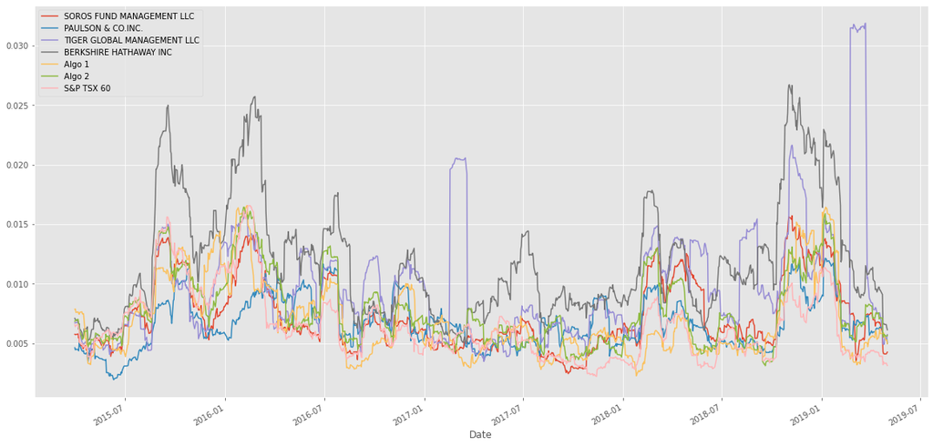

```python
# Calculate the rolling standard deviation for all portfolios using a 21-day window

# Plot the rolling standard deviation
combine_all_df.rolling(window=21).std().plot(figsize=(20,10))
plt.show()
```

### Calculate and plot the correlation

```python
# Calculate the correlation

# Display de correlation matrix
correlation= combine_all_df.corr()
correlation
```

|  | SOROS FUND MANAGEMENT LLC | PAULSON & CO.INC. | TIGER GLOBAL MANAGEMENT LLC | BERKSHIRE HATHAWAY INC | Algo 1 | Algo 2 | S&P TSX 60 |
| --- | --- | --- | --- | --- | --- | --- | --- |
| SOROS FUND MANAGEMENT LLC | 1.000000 | 0.697076 | 0.560964 | 0.750181 | 0.313795 | 0.826667 | 0.673930 |
| PAULSON & CO.INC. | 0.697076 | 1.000000 | 0.433034 | 0.540033 | 0.266363 | 0.674015 | 0.486511 |
| TIGER GLOBAL MANAGEMENT LLC | 0.560964 | 0.433034 | 1.000000 | 0.423524 | 0.161236 | 0.506689 | 0.440583 |
| BERKSHIRE HATHAWAY INC | 0.750181 | 0.540033 | 0.423524 | 1.000000 | 0.289378 | 0.684609 | 0.557250 |
| Algo 1 | 0.313795 | 0.266363 | 0.161236 | 0.289378 | 1.000000 | 0.285455 | 0.310276 |
| Algo 2 | 0.826667 | 0.674015 | 0.506689 | 0.684609 | 0.285455 | 1.000000 | 0.737370 |
| S&P TSX 60 | 0.673930 | 0.486511 | 0.440583 | 0.557250 | 0.310276 | 0.737370 | 1.000000 |

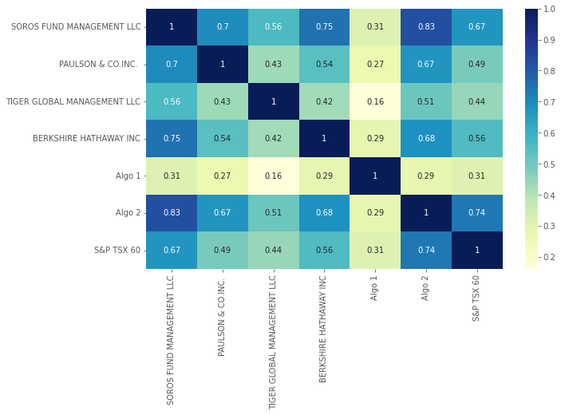

```python
import seaborn as sns
plt.figure(figsize=(10,6))
sns.heatmap(correlation, annot=True, cmap="YlGnBu")
plt.show()
```

### Calculate and Plot Beta for a chosen portfolio and the S&P 60 TSX

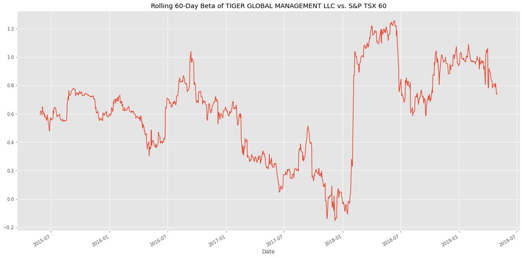

```python
# Calculate covariance of a single portfolio
covariance_berk = combine_all_df["TIGER GLOBAL MANAGEMENT LLC"].rolling(window=60).cov(combine_all_df["S&P TSX 60"])

# Calculate variance of S&P TSX
variance_sp_tsx_60 = combine_all_df['S&P TSX 60'].rolling(window=60).var()

# Computing beta
berk_beta = covariance_berk / variance_sp_tsx_60

# Plot beta trend
berk_beta.plot(figsize=(20,10), title='Rolling 60-Day Beta of TIGER GLOBAL MANAGEMENT LLC vs. S&P TSX 60')
plt.show()
```

## Rolling Statistics Challenge: Exponentially Weighted Average

An alternative way to calculate a rolling window is to take the exponentially weighted moving average. This is like a moving window average, but it assigns greater importance to more recent observations. Try calculating the [`ewm`](https://pandas.pydata.org/pandas-docs/stable/reference/api/pandas.DataFrame.ewm.html) with a 21-day half life for each portfolio, using standard deviation (`std`) as the metric of interest.

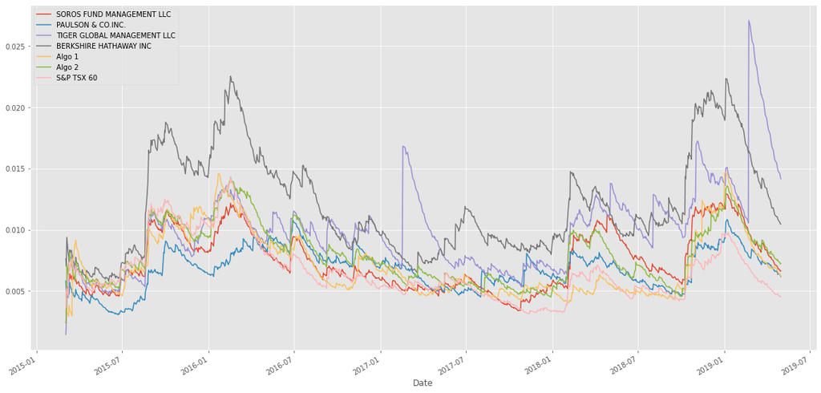

```python
# Use `ewm` to calculate the rolling window
combine_all_df.ewm(halflife=21).std().plot(figsize=(20,10))
plt.show()
```

# Sharpe Ratios

In reality, investment managers and thier institutional investors look at the ratio of return-to-risk, and not just returns alone. After all, if you could invest in one of two portfolios, and each offered the same 10% return, yet one offered lower risk, you'd take that one, right?

### Using the daily returns, calculate and visualize the Sharpe ratios using a bar plot

```python
# Annualized Sharpe Ratios
sharpe_ratio_annualized = (combine_all_df.mean()/ combine_all_df.std()) *np.sqrt(252)
sharpe_ratio_annualized
```

```
SOROS FUND MANAGEMENT LLC      0.286709
PAULSON & CO.INC.             -0.547594
TIGER GLOBAL MANAGEMENT LLC   -0.144455
BERKSHIRE HATHAWAY INC         0.467045
Algo 1                         1.491514
Algo 2                         0.396817
S&P TSX 60                     0.195550
dtype: float64
```

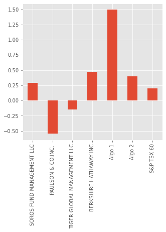

```python
# Visualize the sharpe ratios as a bar plot
sharpe_ratio_annualized.plot.bar(figsize=(5,5))
plt.show()
```

### Determine whether the algorithmic strategies outperform both the market (S&P TSX 60) and the whales portfolios.

---Algorithmic strategy 1 outperforms both the S&P TSX 60 and Whale portfolios

# Create Custom Portfolio

In this section, you will build your own portfolio of stocks, calculate the returns, and compare the results to the Whale Portfolios and the S&P TSX 60.

1. Choose 3-5 custom stocks with at last 1 year's worth of historic prices and create a DataFrame of the closing prices and dates for each stock.
2. Calculate the weighted returns for the portfolio assuming an equal number of shares for each stock.
3. Join your portfolio returns to the DataFrame that contains all of the portfolio returns.
4. Re-run the performance and risk analysis with your portfolio to see how it compares to the others.
5. Include correlation analysis to determine which stocks (if any) are correlated.

## Choose 3-5 custom stocks with at last 1 year's worth of historic prices and create a DataFrame of the closing prices and dates for each stock.

```python
# Reading data from 1st stock
l_df= pd.read_csv("Resources/l_historical.csv")
l_df.rename(columns={'Close':'l'}, inplace=True)
l_df.set_index(pd.to_datetime(l_df['Date'], infer_datetime_format=True), inplace=True)
l_df.drop(columns=['Date', 'Symbol'], inplace=True)
l_df = l_df.sort_index(axis=0, ascending=True)
l_df.head()
```

| Date | l |
| --- | --- |
| 2018-01-02 | 57.99 |
| 2018-01-03 | 57.41 |
| 2018-01-04 | 57.42 |
| 2018-01-05 | 57.42 |
| 2018-01-08 | 56.86 |

```python
# Reading data from 2nd stock

otex_df= pd.read_csv("Resources/otex_historical.csv")
otex_df.rename(columns={'Close':'OTEX'}, inplace=True)
otex_df.set_index(pd.to_datetime(otex_df['Date'], infer_datetime_format=True), inplace=True)
otex_df.drop(columns=['Date','Symbol'], inplace=True)
otex_df = otex_df.sort_index(axis=0, ascending=True)

otex_df.head()
```

| Date | OTEX |
| --- | --- |
| 2018-01-02 | 43.58 |
| 2018-01-03 | 43.07 |
| 2018-01-04 | 42.91 |
| 2018-01-05 | 42.57 |
| 2018-01-08 | 42.16 |

```python
# Reading data from 3rd stock
shop_df= pd.read_csv("Resources/shop_historical.csv")
shop_df.rename(columns={'Close':'Shop'}, inplace=True)
shop_df.set_index(pd.to_datetime(shop_df['Date'], infer_datetime_format=True), inplace=True)
shop_df.drop(columns=['Date', 'Symbol'], inplace=True)
shop_df = shop_df.sort_index(axis=0, ascending=True)
shop_df.tail()
```

| Date | Shop |
| --- | --- |
| 2019-12-20 | 513.22 |
| 2019-12-23 | 511.62 |
| 2019-12-24 | 525.39 |
| 2019-12-27 | 534.76 |
| 2019-12-30 | 517.79 |

```python
# Combine all stocks in a single DataFrame
combine_all_df2= pd.concat([l_df, otex_df, shop_df], axis=1, join="inner")
combine_all_df2.sort_index(inplace=True)
combine_all_df2.head()
```

| Date | l | OTEX | Shop |
| --- | --- | --- | --- |
| 2018-01-02 | 57.99 | 43.58 | 132.06 |
| 2018-01-03 | 57.41 | 43.07 | 135.15 |
| 2018-01-04 | 57.42 | 42.91 | 137.46 |
| 2018-01-05 | 57.42 | 42.57 | 137.26 |
| 2018-01-08 | 56.86 | 42.16 | 139.51 |

```python
# Reset Date index
#combine_all_df2.reset_index(inplace = True)
```

```python
# Reorganize portfolio data by having a column per symbol
combine_all_df2
```

| Date | l | OTEX | Shop |
| --- | --- | --- | --- |
| 2018-01-02 | 57.99 | 43.58 | 132.06 |
| 2018-01-03 | 57.41 | 43.07 | 135.15 |
| 2018-01-04 | 57.42 | 42.91 | 137.46 |
| 2018-01-05 | 57.42 | 42.57 | 137.26 |
| 2018-01-08 | 56.86 | 42.16 | 139.51 |
| ... | ... | ... | ... |
| 2019-12-20 | 67.90 | 58.68 | 513.22 |
| 2019-12-23 | 67.68 | 57.89 | 511.62 |
| 2019-12-24 | 67.67 | 57.44 | 525.39 |
| 2019-12-27 | 67.78 | 57.70 | 534.76 |
| 2019-12-30 | 67.33 | 57.19 | 517.79 |

501 rows × 3 columns

```python
# Calculate daily returns
daily_returns_df2 = combine_all_df2.pct_change()
# Drop NAs
daily_returns_df2.dropna(inplace = True)
# Display sample data
daily_returns_df2.head()
```

| Date | l | OTEX | Shop |
| --- | --- | --- | --- |
| 2018-01-03 | -0.010002 | -0.011703 | 0.023398 |
| 2018-01-04 | 0.000174 | -0.003715 | 0.017092 |
| 2018-01-05 | 0.000000 | -0.007924 | -0.001455 |
| 2018-01-08 | -0.009753 | -0.009631 | 0.016392 |
| 2018-01-09 | 0.008969 | -0.000712 | -0.011254 |

## Calculate the weighted returns for the portfolio assuming an equal number of shares for each stock

```python
# Set weights
weights = [1/3, 1/3, 1/3]

# Calculate portfolio return
portfolio_returns_df2 = daily_returns_df2.dot(weights)
#portfolio_returns_df2.reset_index()
columns=["Custom"]
portfolio_returns_df2=pd.DataFrame(portfolio_returns_df2)
portfolio_returns_df2.columns= columns

# Display sample data
portfolio_returns_df2.head()
```

| Date | Custom |
| --- | --- |
| 2018-01-03 | 0.000565 |
| 2018-01-04 | 0.004517 |
| 2018-01-05 | -0.003126 |
| 2018-01-08 | -0.000997 |
| 2018-01-09 | -0.000999 |

## Join your portfolio returns to the DataFrame that contains all of the portfolio returns

```python
# Join your returns DataFrame to the original returns DataFrame
combine_all_portfolios= pd.concat([portfolio_returns_df2, combine_all_df], axis=1, join="inner")
combine_all_portfolios.sort_index(inplace=True)
combine_all_portfolios.head()
```

| Date | Custom | SOROS FUND MANAGEMENT LLC | PAULSON & CO.INC. | TIGER GLOBAL MANAGEMENT LLC | BERKSHIRE HATHAWAY INC | Algo 1 | Algo 2 | S&P TSX 60 |
| --- | --- | --- | --- | --- | --- | --- | --- | --- |
| 2018-01-03 | 0.000565 | 0.004658 | 0.000027 | 0.001979 | 0.005676 | -0.000890 | 0.008175 | 0.003774 |
| 2018-01-04 | 0.004517 | -0.000914 | 0.004196 | 0.010743 | 0.004065 | -0.000914 | 0.004294 | 0.002528 |
| 2018-01-05 | -0.003126 | 0.004072 | 0.000823 | 0.000737 | 0.022023 | -0.003839 | 0.006405 | -0.003869 |
| 2018-01-08 | -0.000997 | 0.004473 | -0.003739 | 0.005085 | 0.003435 | 0.001653 | 0.000658 | -0.001944 |
| 2018-01-09 | -0.000999 | -0.001028 | 0.000872 | 0.001789 | 0.000708 | -0.001004 | -0.002091 | 0.000097 |

```python
# Only compare dates where return data exists for all the stocks (drop NaNs)
#already done
```

## Re-run the risk analysis with your portfolio to see how it compares to the others

### Calculate the Annualized Standard Deviation

```python
# Calculate the annualized `std`
all_portfolio_daily_std= combine_all_portfolios.std()
all_annualized_std = all_portfolio_daily_std * np.sqrt(252)
all_annualized_std.sort_values(ascending=False)
```

```
BERKSHIRE HATHAWAY INC         0.227445
Custom                         0.224346
TIGER GLOBAL MANAGEMENT LLC    0.219833
SOROS FUND MANAGEMENT LLC      0.145675
Algo 2                         0.137664
Algo 1                         0.120028
PAULSON & CO.INC.              0.114343
S&P TSX 60                     0.099121
dtype: float64
```

### Calculate and plot rolling `std` with 21-day window

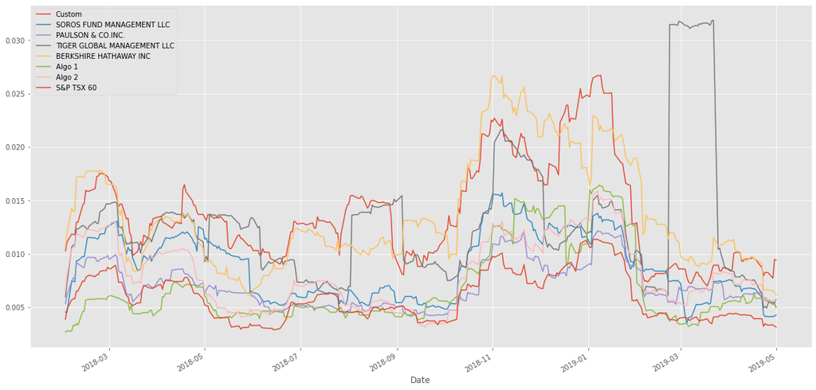

```python
# Calculate rolling standard deviation

# Plot rolling standard deviation
combine_all_portfolios.rolling(window=21).std().plot(figsize=(20,10))
plt.show()
```

### Calculate and plot the correlation

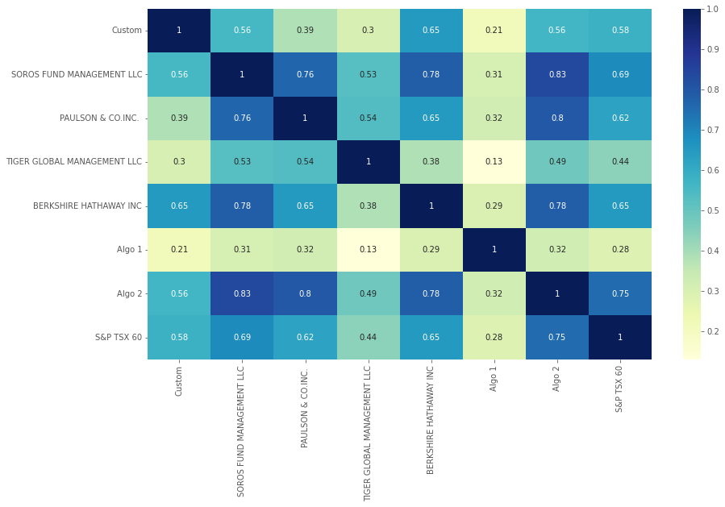

```python
# Calculate and plot the correlation
plt.figure(figsize = (14,8))
sns.heatmap(combine_all_portfolios.corr(), annot=True, cmap="YlGnBu")
plt.show()
```

### Calculate and Plot the 60-day Rolling Beta for Your Portfolio compared to the S&P 60 TSX

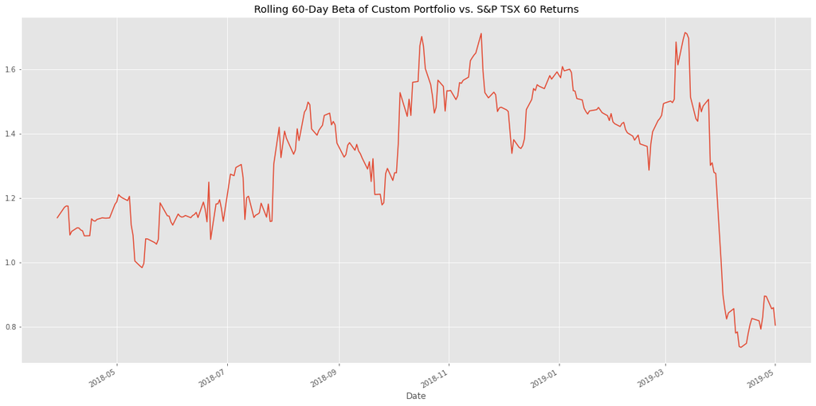

```python
# Calculate and plot Beta
covariance_berk = combine_all_portfolios["Custom"].rolling(window=60).cov(combine_all_portfolios["S&P TSX 60"])
variance_sp500 = combine_all_portfolios['S&P TSX 60'].rolling(window=60).var()
berk_beta = covariance_berk / variance_sp500
berk_beta.plot(figsize=(20,10), title='Rolling 60-Day Beta of Custom Portfolio vs. S&P TSX 60 Returns')
plt.show()
```

### Using the daily returns, calculate and visualize the Sharpe ratios using a bar plot

```python
# Calculate Annualized Sharpe Ratios
sharpe_ratio_annualized_all = (combine_all_portfolios.mean()/ combine_all_portfolios.std()) *np.sqrt(252)
sharpe_ratio_annualized_all
```

```
Custom                         1.564547
SOROS FUND MANAGEMENT LLC     -0.088196
PAULSON & CO.INC.             -0.396282
TIGER GLOBAL MANAGEMENT LLC   -1.391612
BERKSHIRE HATHAWAY INC         0.195907
Algo 1                         1.901461
Algo 2                         0.021394
S&P TSX 60                     0.034651
dtype: float64
```

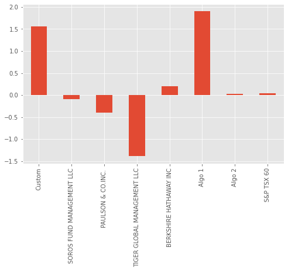

```python
# Visualize the sharpe ratios as a bar plot
sharpe_ratio_annualized_all.plot.bar(figsize=(8,5))
plt.show()
```

### How does your portfolio do?

The custom portfolio outperforms.It has a better ratio of 1.56 compared to SP TSX60. It is performing well